# TP Clustering

Partie 4 : Classification par modèles de mélanges

4modIA / 2023-2024

L’objectif de ce TP est d’illustrer les notions abordées autour des modèles de mélanges.

Les librairies R nécessaires pour ce TP :

```r
## Pour faire le TP
library(mclust)
library(Rmixmod)
library(ggplot2)
library(gridExtra)
library(FactoMineR)
library(factoextra)
library(reshape2)

library(circlize)
library(viridis)
```

# 1 Mélanges gaussiens

## 1.1 Application sur données simulées uni-dimensionnelles

**Question :** A l’aide du code suivant, simulez un jeu de données selon un mélange gaussien en $3$ composantes unidimensionnel. Faites varier les différents paramètres (proportions, moyennes et variances).

```r
# Parameters
a <- 3
b <- 1
mu <- c(-a, 0, a)  # Mean values \mu_k
sigma <- c(b, 0.5, b)  # Standard deviations \sigma_k
prop <- c(0.2, 0.3, 0.5)
n <- 1000

# Simulating data
Z <- rmultinom(1, n, prop)
X <- data.frame(X = c(rnorm(Z[1], mean = mu[1], sd = sigma[1]),
                      rnorm(Z[2], mean = mu[2], sd = sigma[2]),
                      rnorm(Z[3], mean = mu[3], sd = sigma[3])))

labeltrue <- rep(1:3, times = Z)
```

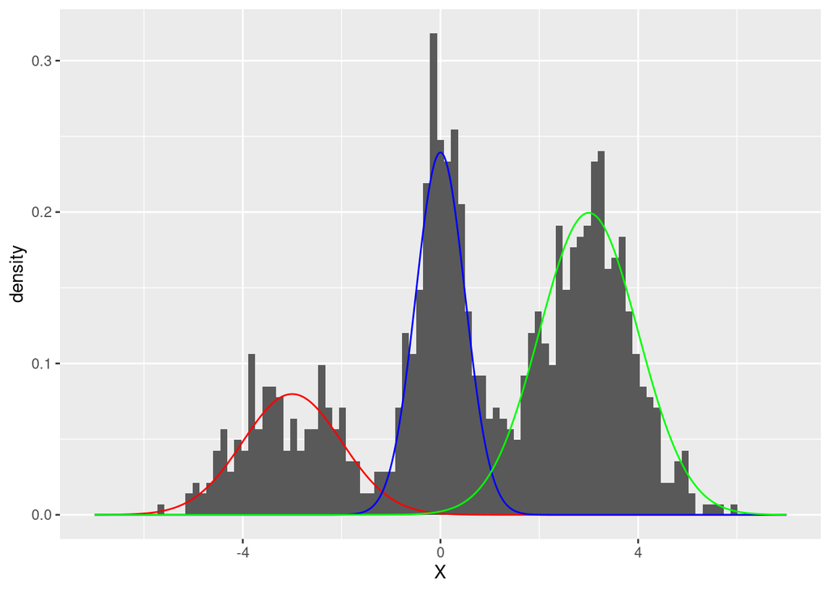

```r
aux<-seq(-(a+4),a+4,0.01)
Y<-data.frame(x=aux,
              y1=(prop[1]*dnorm(aux,mu[1],sigma[1])),
              y2=(prop[2]*dnorm(aux,mu[2],sigma[2])),
              y3=(prop[3]*dnorm(aux,mu[3],sigma[3])))

gvrai<-ggplot(X,aes(x=X))+
  geom_histogram(aes(y = after_stat(density)),bins=100)+
  geom_line(aes(x=x,y=y1),data=Y,col="red")+
  geom_line(aes(x=x,y=y2),data=Y,col="blue")+
  geom_line(aes(x=x,y=y3),data=Y,col="green")
gvrai
```

**Question :** Estimez les paramètres d’un mélange à $K=3$ classes à l’aide de la fonction `Mclust()` de la librairie `mclust`. Comparez la classification obtenue avec les vrais labels.

```r
# Estimation des paramètres Mclust
res <- Mclust(X, G = 3)

# Obtention des clusters
cluster_assignments <- res$classification

# Comparaison avec les vrais labels
table(labeltrue, cluster_assignments)
```

```
##          cluster_assignments
## labeltrue   1   2   3
##         1 194   8   0
##         2   3 318   9
##         3   0  10 458
```

```r
# RandIndex
adjustedRandIndex(cluster_assignments, labeltrue)
```

```
## [1] 0.9119046
```

**Question :** Représentez la densité de mélange estimée sur l’histogramme de l’échantillon simulé.

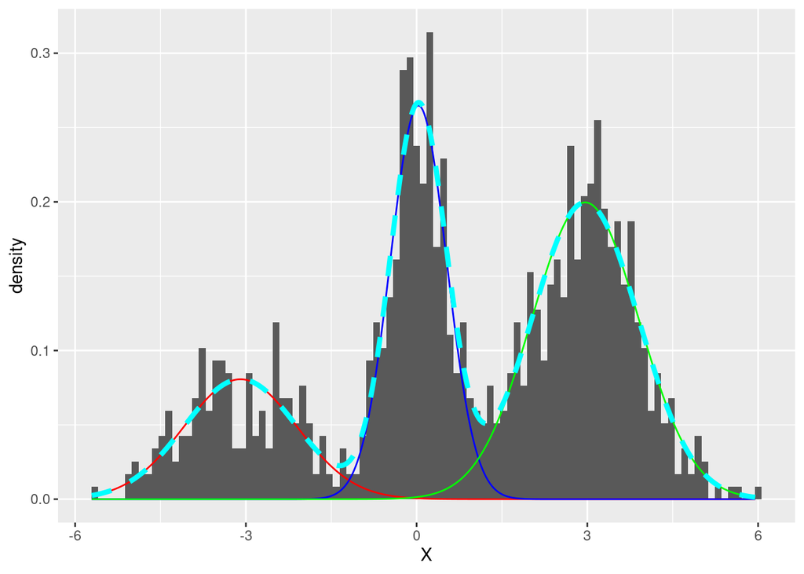

```r
# Estimation de la densité
aux <- seq(min(X$X), max(X$X), length.out = 1000)
y1 <- res$parameters$pro[1] * dnorm(aux, mean = res$parameters$mean[1], sd = sqrt(res$parameters$variance$sigmasq[1]))
y2 <- res$parameters$pro[2] * dnorm(aux, mean = res$parameters$mean[2], sd = sqrt(res$parameters$variance$sigmasq[2]))
y3 <- res$parameters$pro[3] * dnorm(aux, mean = res$parameters$mean[3], sd = sqrt(res$parameters$variance$sigmasq[3]))

# Création du dataframe
MelEstim <- data.frame(x = aux, y1 = y1, y2 = y2, y3 = y3)
MelEstim <- data.frame(MelEstim, Somme = apply(MelEstim[, 2:4], 1, sum))

# Plot
gMelEst <- ggplot(X, aes(x = X)) +
  geom_histogram(aes(y = after_stat(density)), bins = 100) +
  geom_line(aes(x = x, y = y1), data = MelEstim, col = "red") +
  geom_line(aes(x = x, y = y2), data = MelEstim, col = "blue") +
  geom_line(aes(x = x, y = y3), data = MelEstim, col = "green") +
  geom_line(aes(x = x, y = Somme), data = MelEstim, col = "cyan", linetype = "dashed", size = 1.5)
gMelEst
```

**Question :** Calculez les probabilités a posteriori d’appartenance des individus à chacune des trois classes et tracez-les graphiquement.

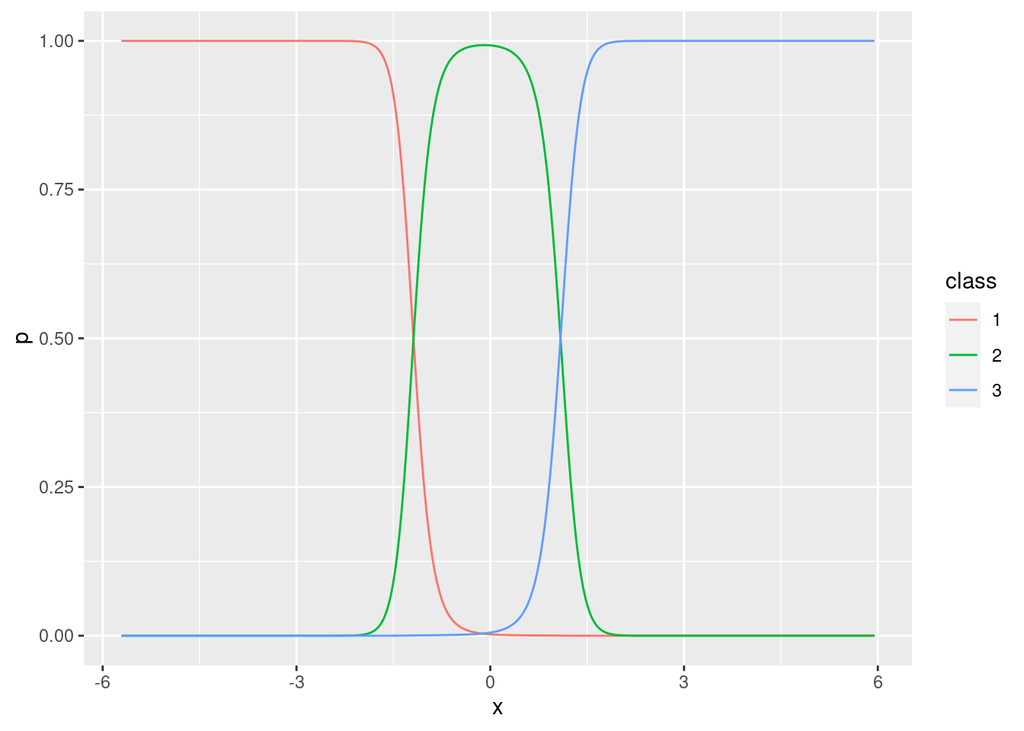

```r
# Création du dataframe
MelProba <- data.frame(x = rep(aux, 3),
                       p = c(MelEstim$y1 / MelEstim$Somme,
                             MelEstim$y2 / MelEstim$Somme,
                             MelEstim$y3 / MelEstim$Somme),
                       class = as.factor(rep(1:3, each = length(aux))))

# Plotting
gprobapost <- ggplot(MelProba, aes(x = x, y = p, col = class)) + geom_line()

gprobapost
```

**Question :** Tracez les boxplots des probabilités d’appartenance maximales par classe. Vous pouvez vous aider de la fonction `apply()`.

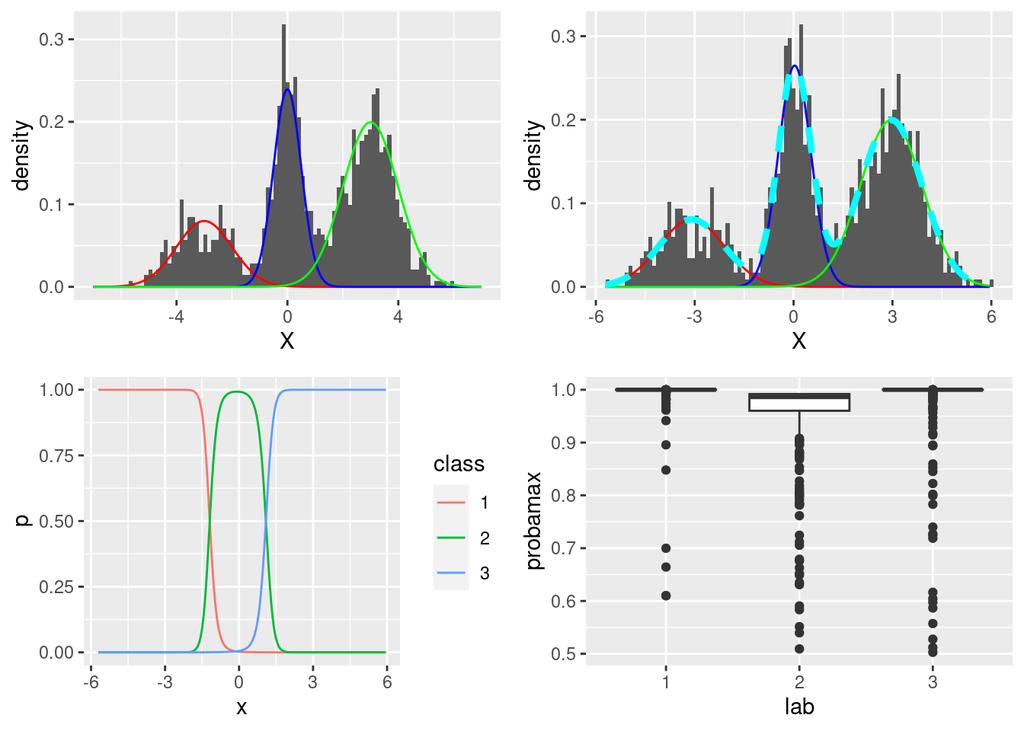

```r
# Création du dataframe
df <- data.frame(lab = as.factor(apply(res$z, 1, which.max)), probamax=apply(res$z, 1, max))

# Boxplot
gprobamax <- ggplot(df, aes(x=lab, y=probamax)) + geom_boxplot()

# Affichage des plots
grid.arrange(gvrai, gMelEst, gprobapost, gprobamax, ncol = 2)
```

## 1.2 Application sur des données simulées dans $\mathbb{R}^2$

On va ici utiliser les données simulées “ex4.1” disponibles dans la librairie `mclust`. Ces données sont simulées selon un mélange de densités gaussiennes, proposées dans Baudry et al (2010). L’objectif est d’étudier l’impact du choix des formes des mélanges considérées et de la différence d’objectif entre les critères BIC et ICL. On va au travers de ce jeu de données simulées simple appréhender la manipulation des fonctions pour le clustering par mélanges gaussiens avec R.

On commence ici par charger les données :

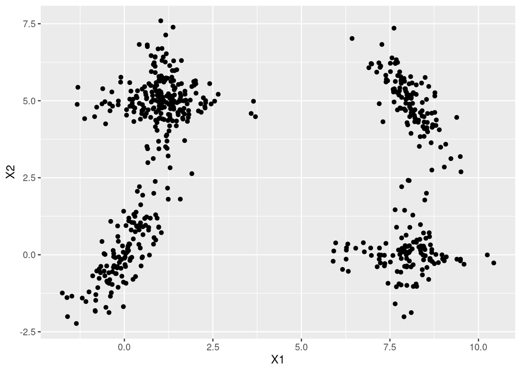

```r
library(mclust)
data(Baudry_etal_2010_JCGS_examples)
Data<-ex4.1
ggplot(Data,aes(x=X1,y=X2))+geom_point()
```

### 1.2.1 Mélanges gaussiens diagonaux

Dans cette section, on va considérer une collection de modèles de mélanges gaussiens avec un nombre de composantes $K$ variant entre $2$ et $10$ et des matrices de variance-covariance diagonales.

**Question :** A l’aide de la fonction `Mclust()`, estimez les paramètres des mélanges gaussiens considérés. Vous pouvez consulter l’aide de la fonction `mclustModelNames()` pour le choix des formes des mélanges.

```r
# Estimation des paramètres pour les mélanges gaussiens avec des matrices de covariance diagonales
resBICdiag <- Mclust(Data, G = 2:10, modelNames = c("EII", "VII", "EEI", "VEI", "EVI", "VVI"))
summary(resBICdiag)
```

```
## ----------------------------------------------------
## Gaussian finite mixture model fitted by EM algorithm
## ----------------------------------------------------
##
## Mclust EVI (diagonal, equal volume, varying shape) model with 10 components:
##
##  log-likelihood   n df       BIC       ICL
##       -1993.944 600 40 -4243.764 -4470.305
##
## Clustering table:
##   1   2   3   4   5   6   7   8   9  10
##  48  70  82 145  16  53  74   8  72  32
```

**Question :** A l’aide de la fonction `fviz_mclust_bic()`, visualisez le comportement du critère BIC sur la collection de modèles. Quel modèle est sélectionné ? Contrôlez à l’aide de `summary(resBICdiag)`.

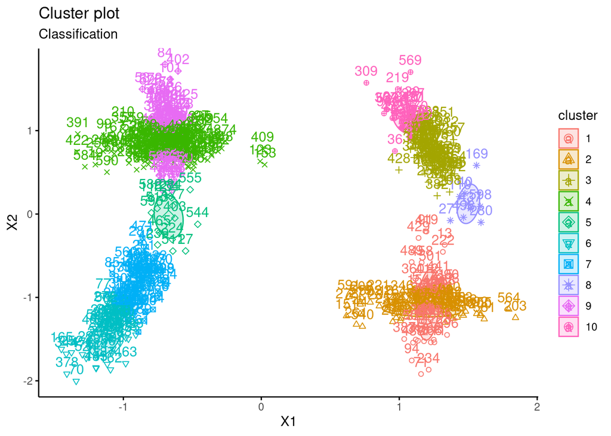

```r
fviz_mclust(resBICdiag,what=c("classification", "uncertainty", "BIC"))
```

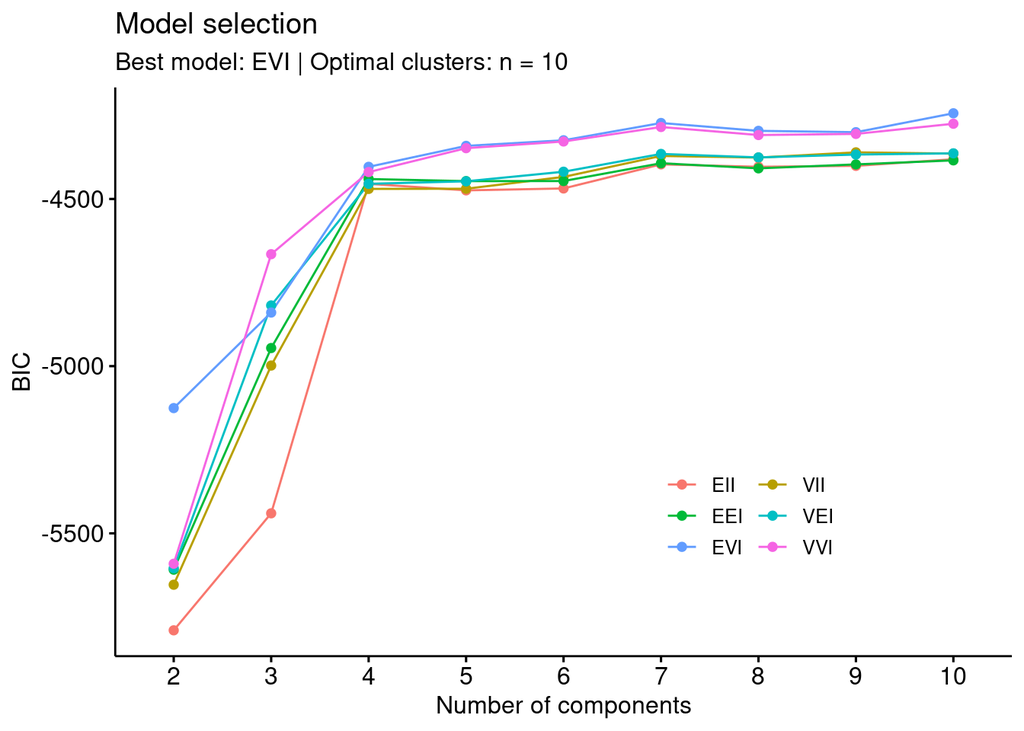

```r
fviz_mclust_bic(resBICdiag,what=c("classification", "uncertainty", "BIC"))
```

```r
summary(resBICdiag)
```

```
## ----------------------------------------------------
## Gaussian finite mixture model fitted by EM algorithm
## ----------------------------------------------------
##
## Mclust EVI (diagonal, equal volume, varying shape) model with 10 components:
##
##  log-likelihood   n df       BIC       ICL
##       -1993.944 600 40 -4243.764 -4470.305
##
## Clustering table:
##   1   2   3   4   5   6   7   8   9  10
##  48  70  82 145  16  53  74   8  72  32
```

Modèle EVI choisi : diagonal, même volume, forme variantes.

**Question :** Tracez la classification obtenue sur le nuage de points (vous pouvez utiliser la fonction `fviz_cluster()`). Comment est obtenue cette classification à partir du mélange gaussien retenu ? Quels sont les effectifs par classe ? Contrôlez les probabilités a posterori d’appartenance.

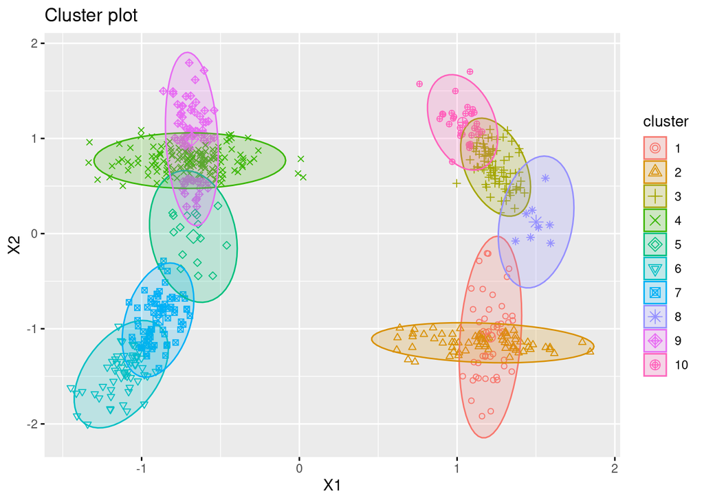

```r
# Visualisation du clustering
fviz_cluster(resBICdiag, data = Data, ellipse.type = "norm", geom = "point")
```

```r
# Effectifs par classe
table(resBICdiag$classification)
```

```
##
##   1   2   3   4   5   6   7   8   9  10
##  48  70  82 145  16  53  74   8  72  32
```

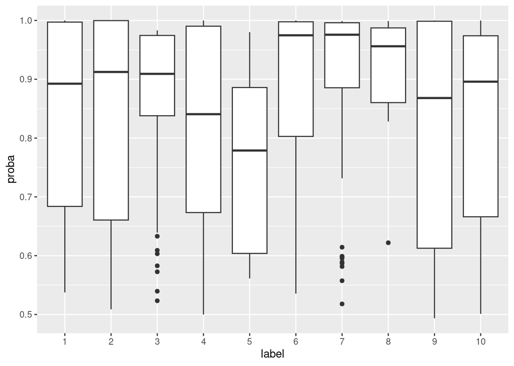

```r
# Boxplot des probabilités a posteriori maximales
Aux <- data.frame(label = as.factor(apply(resBICdiag$z, 1, which.max)), proba = apply(resBICdiag$z, 1, max))
ggplot(Aux,aes(x=label,y=proba))+geom_boxplot()
```

**Question :** Quel mélange gaussien est retenu avec le critère ICL ? Vous utiliserez la fonction `mclustICL()`. Etudiez la classification alors déduite.

```r
# Estimation des paramètres avec le critère ICL
resICL <- mclustICL(Data, G = 2:10, modelNames = c("EII", "VII", "EEI", "VEI", "EVI", "VVI"))

# Summary
summary(resICL)
```

```
## Best ICL values:
##              EVI,4       VVI,4      EEI,4
## ICL      -4407.029 -4422.87307 -4446.3616
## ICL diff     0.000   -15.84396   -39.3325
```

On choisi le modèle “EVI” avec 4 classes.

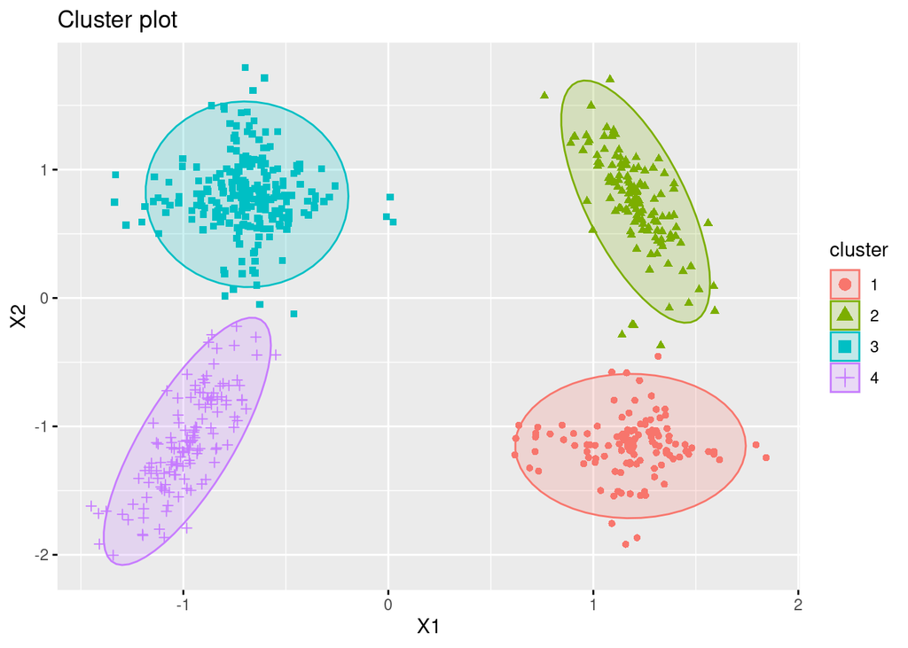

```r
# Selection du modèle EVI avec 4 classes
modICL <- Mclust(Data, G=4, modelNames = "EVI")

# Visualisation du clustering
fviz_cluster(modICL, data = Data, ellipse.type = "norm", geom = "point")
```